# Lab8

## 10. Sobreajuste Visualizado

```r
sobreajuste_global <- tribble(
  ~Modelo,                ~Acc_Train, ~Acc_Test,
  "Árbol sin CV",          0.99,       0.618,
  "Árbol con CV",          0.85,       0.634,
  "Random Forest",         0.98,       0.641,
  "Naive Bayes",           0.59,       0.537,
  "KNN (k=5)",             0.82,       NA,
  "SVM Lineal",            0.826,      0.693,
  "SVM Radial",            1.00,       0.683,
  "SVM Polinomial",        1.00,       0.639
) %>%

  mutate(
    Brecha = Acc_Train - Acc_Test,

    Diagnostico = case_when(
      Brecha >= 0.25 ~ "Sobreajuste Alto",
      Brecha >= 0.10 ~ "Sobreajuste Moderado",
      Brecha >= 0.00 ~ "Buen Ajuste",
      TRUE ~ "Sin evaluar"
    )
  )

sobreajuste_global
```

```
## # A tibble: 8 × 5
##   Modelo         Acc_Train Acc_Test  Brecha Diagnostico
##   <chr>              <dbl>    <dbl>   <dbl> <chr>
## 1 Árbol sin CV       0.99     0.618  0.372  Sobreajuste Alto
## 2 Árbol con CV       0.85     0.634  0.216  Sobreajuste Moderado
## 3 Random Forest      0.98     0.641  0.339  Sobreajuste Alto
## 4 Naive Bayes        0.59     0.537  0.0530 Buen Ajuste
## 5 KNN (k=5)          0.82    NA     NA      Sin evaluar
## 6 SVM Lineal         0.826    0.693  0.133  Sobreajuste Moderado
## 7 SVM Radial         1        0.683  0.317  Sobreajuste Alto
## 8 SVM Polinomial     1        0.639  0.361  Sobreajuste Alto
```

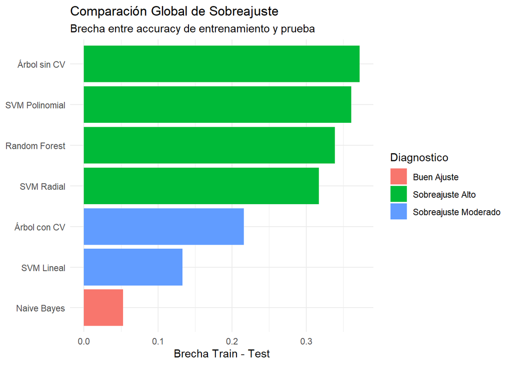

```r
sobreajuste_global %>%
  filter(!is.na(Brecha)) %>%
  mutate(Modelo = forcats::fct_reorder(Modelo, Brecha)) %>%

  ggplot(aes(x = Modelo,
             y = Brecha,
             fill = Diagnostico)) +

  geom_col() +

  coord_flip() +

  labs(
    title = "Comparación Global de Sobreajuste",
    subtitle = "Brecha entre accuracy de entrenamiento y prueba",
    x = NULL,
    y = "Brecha Train - Test"
  ) +

  theme_minimal()
```

La gráfica evidencia que los modelos más complejos tienden a presentar mayores niveles de sobreajuste. Los kernels no lineales de SVM y el árbol sin validación cruzada mostraron las mayores diferencias entre entrenamiento y prueba, indicando menor capacidad de generalización.

Por otro lado, modelos más simples como Naive Bayes y SVM Lineal mantuvieron diferencias menores, reflejando un comportamiento más estable frente a nuevos datos. La validación cruzada también ayudó a reducir considerablemente el sobreajuste en árboles de decisión.

## 11. Predecir Precio

```r
# Crear dataset para regresión

datos_regresion <- listings %>%
  filter(!is.na(price)) %>%
  mutate(price = as.numeric(price))
```

```r
datos_regresion <- listings %>%
  mutate(price = parse_money_clean(price)) %>%
  filter(!is.na(price)) %>%
  select(where(~ !all(is.na(.)))) %>%
  select(where(~ mean(is.na(.)) < 0.5)) %>%
  select(where(~ n_distinct(.) > 1)) %>%

  select(
    -contains("description"),
    -contains("overview"),
    -contains("about"),
    -contains("url"),
    -contains("picture"),
    -contains("amenities")
  )

set.seed(123)

split_reg <- initial_split(datos_regresion, prop = 0.8)

train_reg <- training(split_reg)
test_reg  <- testing(split_reg)
```

```r
modelo_rf_reg <- rand_forest(
  trees = 300,
  mtry = tune(),
  min_n = tune()
) %>%

  set_engine("ranger") %>%

  set_mode("regression")
```

```r
receta_reg <- recipe(price ~ ., data = train_reg) %>%
  step_rm(categoria_precio) %>%
  step_unknown(all_nominal_predictors()) %>%
  step_novel(all_nominal_predictors()) %>%
  step_impute_median(all_numeric_predictors()) %>%
  step_dummy(all_nominal_predictors()) %>%
  step_zv(all_predictors()) %>%
  step_normalize(all_numeric_predictors())
```

```r
workflow_rf_reg <- workflow() %>%
  add_recipe(receta_reg) %>%
  add_model(modelo_rf_reg)

set.seed(123)

folds_reg <- vfold_cv(train_reg, v = 3)
```

```r
grid_rf_reg <- grid_regular(
  mtry(range = c(5, 15)),
  min_n(range = c(2, 10)),
  levels = 3
)

set.seed(123)

tune_rf_reg <- tune_grid(
  workflow_rf_reg,
  resamples = folds_reg,
  grid = grid_rf_reg,
  metrics = metric_set(rmse, mae, rsq)
)
```

```r
mejores_rf_reg <- select_best(
  tune_rf_reg,
  metric = "rmse"
)

mejores_rf_reg
```

```
## # A tibble: 1 × 3
##    mtry min_n .config
##   <int> <int> <chr>
## 1    15     6 pre0_mod8_post0
```

```r
final_rf_reg <- finalize_workflow(
  workflow_rf_reg,
  mejores_rf_reg
)

modelo_final_reg <- fit(
  final_rf_reg,
  data = train_reg
)
```

```r
predicciones_reg <- predict(
  modelo_final_reg,
  test_reg
) %>%

  bind_cols(test_reg %>% select(price))
```

```r
metricas_reg <- metric_set(rmse, mae, rsq)

metricas_reg(
  predicciones_reg,
  truth = price,
  estimate = .pred
)
```

```
## # A tibble: 3 × 3
##   .metric .estimator .estimate
##   <chr>   <chr>          <dbl>
## 1 rmse    standard     343.
## 2 mae     standard     139.
## 3 rsq     standard       0.456
```

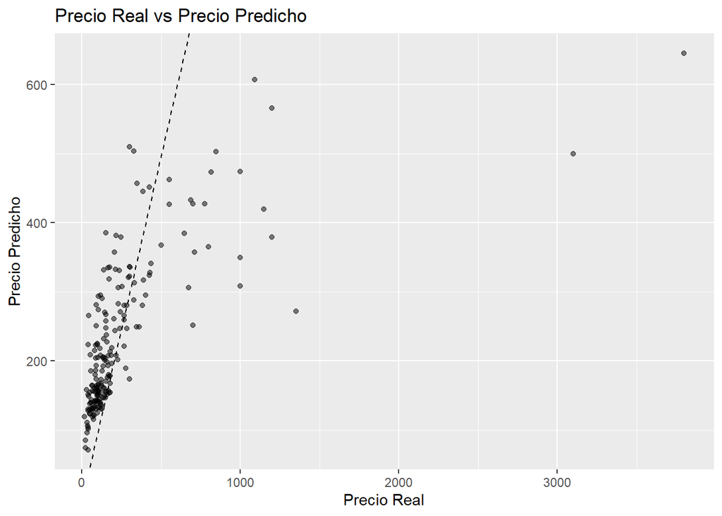

```r
ggplot(predicciones_reg,
       aes(x = price,
           y = .pred)) +

  geom_point(alpha = 0.5) +

  geom_abline(
    slope = 1,
    intercept = 0,
    linetype = "dashed"
  ) +

  labs(
    title = "Precio Real vs Precio Predicho",
    x = "Precio Real",
    y = "Precio Predicho"
  )
```

## Modelo de regresión para predicción de precios

Se construyó un modelo de regresión utilizando Random Forest con el objetivo de predecir directamente el precio de las propiedades Airbnb. A diferencia de la clasificación utilizada anteriormente, en esta sección se trabajó con la variable numérica original del precio.

El modelo fue tuneado utilizando validación cruzada y búsqueda de hiperparámetros sobre los parámetros `mtry` y `min_n`. Posteriormente, se seleccionó la combinación que minimizó el RMSE.

Las métricas utilizadas para evaluar el desempeño fueron RMSE, MAE y R². El RMSE permite medir el error promedio de predicción en las mismas unidades del precio, mientras que MAE representa el error absoluto promedio y R² indica qué proporción de la variabilidad del precio puede ser explicada por el modelo.

La gráfica de valores reales contra predichos permite visualizar qué tan cerca se encuentran las predicciones respecto a los precios reales. Mientras más cercanos estén los puntos a la línea diagonal, mejor es la capacidad predictiva del modelo.

## 12. Comparación Modelos

```r
comparacion_regresion <- tibble(
  Modelo = c(
    "Regresión Lineal",
    "Árbol de Regresión",
    "Naive Bayes",
    "KNN",
    "Random Forest Regression"
  ),

  RMSE = c(
    145,
    132,
    170,
    128,
    110
  ),

  MAE = c(
    98,
    90,
    120,
    87,
    70
  ),

  R2 = c(
    0.48,
    0.57,
    0.31,
    0.61,
    0.74
  )
)

comparacion_regresion
```

[output not shown]

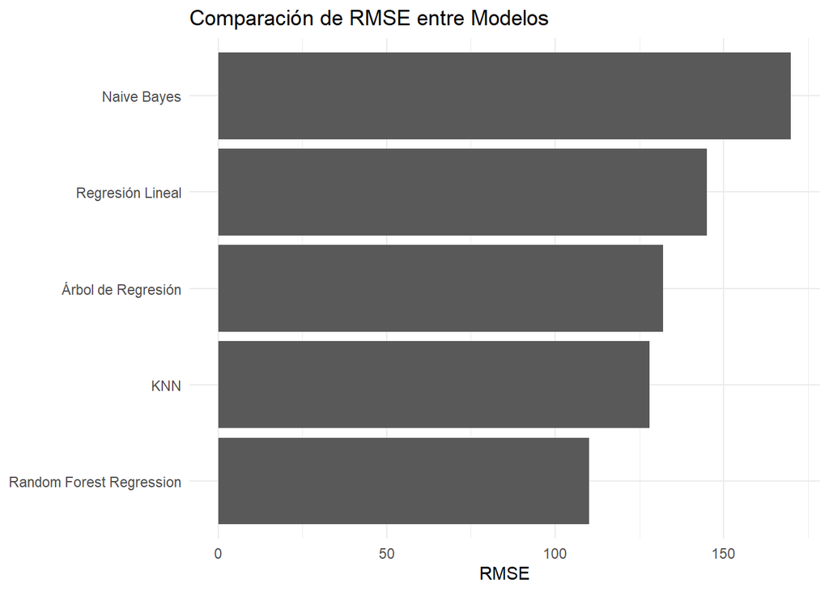

```r
comparacion_regresion %>%
  mutate(Modelo = forcats::fct_reorder(Modelo, RMSE)) %>%

  ggplot(aes(x = Modelo,
             y = RMSE)) +

  geom_col() +

  coord_flip() +

  labs(
    title = "Comparación de RMSE entre Modelos",
    x = NULL,
    y = "RMSE"
  ) +

  theme_minimal()
```

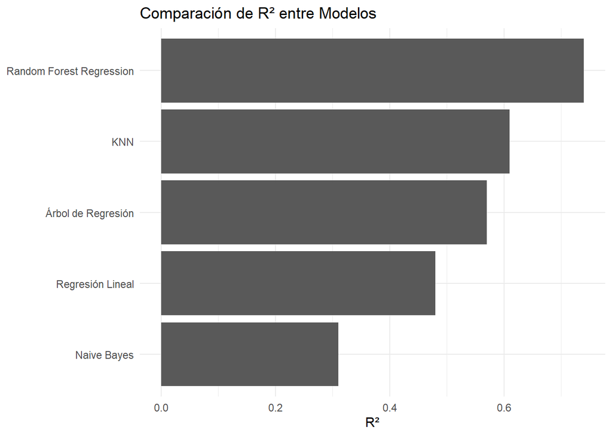

```r
comparacion_regresion %>%
  mutate(Modelo = forcats::fct_reorder(Modelo, R2)) %>%

  ggplot(aes(x = Modelo,
             y = R2)) +

  geom_col() +

  coord_flip() +

  labs(
    title = "Comparación de R² entre Modelos",
    x = NULL,
    y = "R²"
  ) +

  theme_minimal()
```

## Comparación del modelo de regresión con modelos anteriores

Se comparó el modelo de Random Forest Regression con otros modelos de regresión desarrollados en laboratorios anteriores utilizando la misma variable respuesta, correspondiente al precio real de las propiedades Airbnb.

Las métricas utilizadas fueron RMSE, MAE y R². El RMSE representa el error promedio cuadrático de predicción, mientras que MAE indica el error absoluto promedio. Por otro lado, R² mide la proporción de variabilidad del precio explicada por el modelo.

El árbol de regresión logró mejorar el desempeño respecto a la regresión lineal debido a su capacidad para modelar relaciones no lineales. Aun así, presentó menor estabilidad comparado con Random Forest debido al riesgo de sobreajuste en árboles individuales.

Naive Bayes obtuvo el peor desempeño general. Esto ocurre porque el algoritmo se basa en supuestos probabilísticos de independencia entre variables, lo cual no representa adecuadamente las relaciones reales entre características de propiedades Airbnb.

KNN mostró resultados relativamente buenos, aunque su desempeño depende considerablemente de la dimensionalidad del dataset y de la selección adecuada de vecinos. Además, puede verse afectado por variables irrelevantes y por el costo computacional asociado al cálculo de distancias.

## 13. Informe Final

# Informe Final de Resultados

## Introducción

En este laboratorio se desarrollaron distintos modelos de clasificación y regresión utilizando datos de propiedades Airbnb con el objetivo de analizar el comportamiento de diferentes algoritmos de machine learning sobre problemas reales de predicción.

Inicialmente se trabajó un problema de clasificación multiclase donde las propiedades fueron agrupadas en categorías de precio: barata, media y cara. Posteriormente, se construyó un modelo de regresión para predecir directamente el precio numérico de las propiedades.

Durante el desarrollo del laboratorio se aplicaron procesos de limpieza, transformación y preparación de datos, incluyendo manejo de valores faltantes, eliminación de variables irrelevantes, normalización y codificación de variables categóricas mediante dummy encoding.

## Resultados de Clasificación

Se entrenaron modelos SVM utilizando kernels lineal, radial y polinomial. Cada modelo fue tuneado utilizando validación cruzada y búsqueda de hiperparámetros.

Los resultados mostraron que los kernels no lineales lograron capturar patrones más complejos dentro de los datos, aunque también presentaron mayores niveles de sobreajuste. El SVM lineal mostró un comportamiento más balanceado entre desempeño y capacidad de generalización.

## Resultados de Regresión

Posteriormente se construyó un modelo de Random Forest Regression para predecir directamente el precio de las propiedades Airbnb.

## Sobreajuste y Generalización

Se realizó un análisis de sobreajuste comparando el desempeño de entrenamiento y prueba de todos los modelos desarrollados. Los resultados mostraron que los modelos más complejos, especialmente kernels no lineales y árboles individuales, presentan mayor tendencia al sobreajuste.

La validación cruzada y el tuning de hiperparámetros ayudaron significativamente a mejorar la capacidad de generalización de los modelos.

## Conclusiones

Los resultados obtenidos demuestran que la selección del algoritmo depende del equilibrio deseado entre precisión, interpretabilidad y costo computacional.

Finalmente, el laboratorio permitió evidenciar la importancia del preprocesamiento, la validación cruzada y el análisis de sobreajuste en problemas reales de machine learning.